# DEG analysis after resequencing of the 3 last batches, excluding Nitrogen, LFC=1, excluding T0, Combined analysis of nutrition and AZD

Thomas Dobrenel and Nicolas Delhomme

2019-12-28

# 1 Setup

- Set the working dir

```r
setwd("/mnt/picea/projects/arabidopsis/jhanson/arabidopsis-nutrition-TOR/Nutrition_AZD")
```

- Load libraries

```r
suppressPackageStartupMessages({
    library(data.table)
    library(DESeq2)
    library(gplots)
    library(here)
    library(hyperSpec)
    library(limma)
    library(LSD)
    library(magrittr)
    library(matrixStats)
    library(parallel)
    library(pander)
    library(plotly)
    library(RColorBrewer)
    library(scatterplot3d)
    library(tidyverse)
    library(tximport)
    library(VennDiagram)
    library(vsn)
})
```

- Source some helper functions

```r
suppressPackageStartupMessages({
    source("~/Git/UPSCb/UPSCb-common/src/R/featureSelection.R")
    source("~/Git/UPSCb/UPSCb-common/src/R/gopher.R")
    source("~/Git/UPSCb/UPSCb-common/src/R/plot.multidensity.R")
    source("~/Git/UPSCb/UPSCb-common/src/R/volcanoPlot.R")
})
```

- Cutoff Different from Schurch et al., RNA, 2016 (LFC at 1 instead of 0,5)

```r
lfc <- 1
FDR <- 0.01
```

- Create palettes

```r
pal <- c(brewer.pal(8,"Dark2"),1)
pal2 <- brewer.pal(9,"Paired") #require package RColorBrewer
cols <- rainbow(17)
hpal <- colorRampPalette(c("blue","white","red"))(100)
```

- Register the default plot margin

```r
mar <- par("mar")
```

# 2 Raw data

## 2.1 Loading of sample information

- Read the sample information

```r
samples <- read.csv("~/Git/UPSCb/projects/arabidopsis-nutrition-TOR/doc/samples3.csv")
```

- Remove unnecessary samples

```r
samples %<>% filter(!grepl("P11554_1",SciLifeID)) %>%
    filter(! SciLifeID %in% c("P13406_101",
                              "P14066_128",
                              "P14066_133",
                              "P13406_102",
                              "P14066_131")) %>%
    filter(! Nutrition == "PKS") %>%
    mutate(Nutrition,Nutrition=relevel(Nutrition,"NPS")) %>%
    mutate(AZD,AZD=relevel(AZD,"DMSO"))

samples <- samples[order(samples$Timepoint, samples$Nutrition, samples$AZD),]

samples %<>% mutate(Timepoint,Timepoint=factor(paste0("T",Timepoint)))
```

### 2.1.1 Load the data

- Call the data

```r
filenames <- list.files("../Salmon",
                        recursive = TRUE,
                        pattern = "quant.sf",
                        full.names = TRUE)
```

- Name the data

```r
names(filenames) <- sub("_S.*","",sapply(strsplit(filenames, "/"), .subset, 3))
```

- Match data <=> sample list

```r
filenames <- filenames[match(samples$SciLifeID,names(filenames))]
filenames <-filenames[!is.na(names(filenames))]
samples <- samples[match(names(filenames),samples$SciLifeID),]
```

- Annotate the samples

```r
samples$Conditions <- factor(paste(samples$Timepoint,samples$Nutrition,samples$AZD,sep="_"))
samples$Batch <- factor(substr(samples$SciLifeID,1,8))
```

# 3 Expression data

Read the expression at the transcript level

```r
tx <- suppressMessages(tximport(files = filenames,
                                type = "salmon",
                                txOut = TRUE))
```

summarise to genes

```r
tx2gene <- data.frame(TXID=rownames(tx$counts),
                      GENEID=sub("\\.[0-9]+","",rownames(tx$counts)))
gx <- summarizeToGene(tx,tx2gene=tx2gene)
```

```
## summarizing abundance
```

```
## summarizing counts
```

```
## summarizing length
```

```r
kg <- round(gx$counts)
```

Sanity check

```r
stopifnot(all(colnames(kg) == samples$SciLifeID))
```

## 3.1 Raw data export

```r
#dir.create(file.path("analysis_Tom","salmon"),showWarnings=FALSE,recursive=TRUE)
#write.table(kg,file="/mnt/picea/projects/arabidopsis/jhanson/arabidopsis-nutrition-TOR/analysis_Tom/nutrition-unormalised-gene-expression_data.csv")
#save(kg, samples, file = "/mnt/picea/projects/arabidopsis/jhanson/arabidopsis-nutrition-TOR/analysis_Tom/counts.rda")
```

## 3.2 Preliminary validations

### 3.2.1 Check for the genes that are never expressed

```r
sel <- rowSums(kg) == 0
sprintf("%s%% (%s) of %s genes are not expressed",
        round(sum(sel) * 100/ nrow(kg),digits=1),
        sum(sel),
        nrow(kg))
```

```
## [1] "17.9% (5793) of 32310 genes are not expressed"
```

# 4 Data normalisation

For visualization, the data is submitted to a variance stabilization transformation using DESeq2. The dispersion is estimated independently of the sample type

```r
dds <- DESeqDataSetFromMatrix(
    countData = kg,
    colData = samples,
    design = ~ Conditions)
dds <- estimateSizeFactors(dds)
```

## 4.1 Perform a Variance Stabilizing Transformation for plotting

```r
vst <- varianceStabilizingTransformation(dds,blind=FALSE)
vsd <- assay(vst)
vsd <- vsd - min(vsd)
```

Write out

```r
#write.csv(vst,"/mnt/picea/projects/arabidopsis/jhanson/arabidopsis-nutrition-TOR/analysis_Tom/library-size-normalized_variance-stabilized_data_nutrition.csv")
```

# 5 Multivariate analysis

## 5.1 PCA

Principal Component Analysis on the normalized data * Establishment of the PCA

```r
conditions1 <- factor(paste(samples$AZD,samples$Nutrition,sep="_"))
pc <- prcomp(t(vsd))
percent <- round(summary(pc)$importance[2,]*100);percent
```

```
##  PC1  PC2  PC3  PC4  PC5  PC6  PC7  PC8  PC9 PC10 PC11 PC12 PC13 PC14 PC15 PC16
##   43   24   13    6    4    2    1    1    1    1    0    0    0    0    0    0
## PC17 PC18 PC19 PC20 PC21 PC22 PC23 PC24 PC25 PC26 PC27 PC28 PC29 PC30 PC31 PC32
##    0    0    0    0    0    0    0    0    0    0    0    0    0    0    0    0
## PC33 PC34 PC35 PC36 PC37 PC38 PC39 PC40 PC41 PC42 PC43 PC44
##    0    0    0    0    0    0    0    0    0    0    0    0
```

- Graphical representation of PC1 x PC2

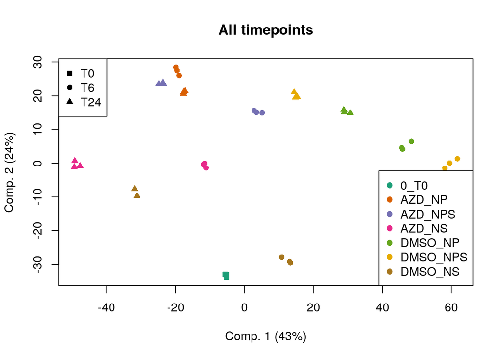

```r
conds <- droplevels(conditions1)
plot(pc$x[,1],
     pc$x[,2],
     xlab=paste("Comp. 1 (",percent[1],"%)",sep=""),
     ylab=paste("Comp. 2 (",percent[2],"%)",sep=""),
     col=pal[as.integer(conds)],
     pch=c(15,16,17)[as.factor(samples$Timepoint)],
     main="All timepoints")

legend("bottomright",pch=19,
       col=pal[1:nlevels(conds)],
       legend=levels(conds))

legend("topleft",pch=c(15,16,17),
       col="black",
       legend=c("T0","T6","T24"))
```

- Graphical representation of PC2 x PC3

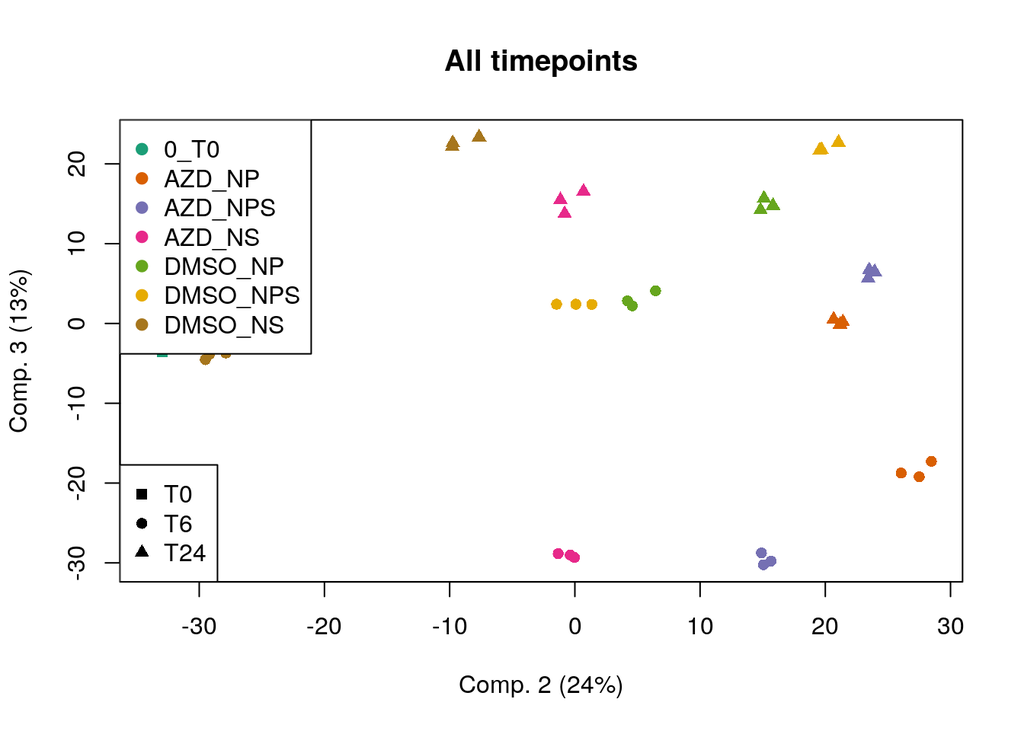

```r
plot(pc$x[,2],
     pc$x[,3],
     xlab=paste("Comp. 2 (",percent[2],"%)",sep=""),
     ylab=paste("Comp. 3 (",percent[3],"%)",sep=""),
     col=pal[as.integer(conds)],
     pch=c(15,16,17)[as.factor(samples$Timepoint)],
     main="All timepoints")

legend("topleft",pch=19,
       col=pal[1:nlevels(conds)],
       legend=levels(conds))

legend("bottomleft",pch=c(15,16,17),
       col="black",
       legend=c("T0","T6","T24"))
```

- Graphical representation of PC1 x PC3

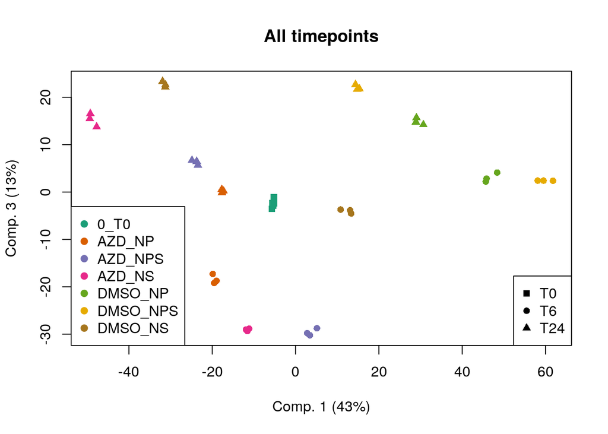

```r
plot(pc$x[,1],
     pc$x[,3],
     xlab=paste("Comp. 1 (",percent[1],"%)",sep=""),
     ylab=paste("Comp. 3 (",percent[3],"%)",sep=""),
     col=pal[as.integer(conds)],
     pch=c(15,16,17)[as.factor(samples$Timepoint)],
     main="All timepoints")

legend("bottomleft",pch=19,
       col=pal[1:nlevels(conds)],
       legend=levels(conds))

legend("bottomright",pch=c(15,16,17),
       col="black",
       legend=c("T0","T6","T24"))
```

# 6 Differential expression based on the nutrition and treatment at T6

## 6.1 Filtration of samples based on timepoint

```r
samples %<>% mutate(Conditions,Conditions=relevel(Conditions,"T6_NPS_DMSO"))
sel <- samples$Timepoint %in% c("T6")
suppressMessages(dds <- DESeqDataSetFromMatrix(
    countData = kg[,sel],
    colData = samples[sel,],
    design = ~ Nutrition * AZD))
```

## 6.2 Differential expression analysis

```r
dds <- DESeq(dds)
```

## 6.3 Variance Stabilising Transformation

### 6.3.1 Perform a Variance Stabilizing Transformation for plotting

```r
vst <- varianceStabilizingTransformation(dds,blind=FALSE)
vsd <- assay(vst)
vsd <- vsd - min(vsd)
```

## 6.4 Contrasts to NPS_DMSO

The contrast by default is the first one (not Intercept)

```r
resultsNames(dds)
```

```
## [1] "Intercept"           "Nutrition_NP_vs_NPS" "Nutrition_NS_vs_NPS"
## [4] "AZD_AZD_vs_DMSO"     "NutritionNP.AZDAZD"  "NutritionNS.AZDAZD"
```

### 6.4.1 Nutrition effect of carbon starvation

```r
# See output of "Condition design"
```

### 6.4.2 Nutrition effect of phosphorus starvation

```r
# See output of "Condition design"
```

### 6.4.3 Effect of AZD-8055

```r
# See output of "Condition design"
```

### 6.4.4 Differential response of AZD & sugar starvation from AZD + sugar starvation responses

#### 6.4.4.1 Extraction of the results from the DESeq analysis

```r
res <- results(dds,name = "NutritionNP.AZDAZD")
data <- data.frame(rownames(res), res$log2FoldChange, res$padj)
write.table(data, file = "NutritionNP.AZDAZD_6h.csv", sep = ";", row.names = FALSE, dec=",")
cutoffs <- abs(res$log2FoldChange) >= lfc & ! is.na(res$padj) & res$padj <= FDR
cutoff1 <- res$log2FoldChange >= lfc & ! is.na(res$padj) & res$padj <= FDR
cutoff2 <- res$log2FoldChange <= -lfc & ! is.na(res$padj) & res$padj <= FDR
Azd_NP6hrs <- rownames(res[cutoffs,])
Azd_NPLow6hrs <- rownames(res[cutoff2,])
Azd_NPHigh6hrs <- rownames(res[cutoff1,])

message(sprintf("There are %s genes that are differentially expressed",sum(cutoffs)))
```

```
## There are 62 genes that are differentially expressed
```

```r
message(sprintf("There are %s genes that are induced",sum(cutoff1)))
```

```
## There are 51 genes that are induced
```

```r
message(sprintf("There are %s genes that are repressed",sum(cutoff2)))
```

```
## There are 11 genes that are repressed
```

#### 6.4.4.2 MA plot

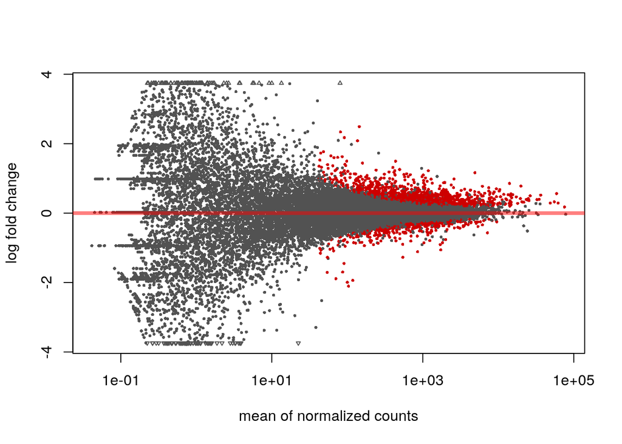

```r
DESeq2::plotMA(res)
```

#### 6.4.4.3 Volcano plot

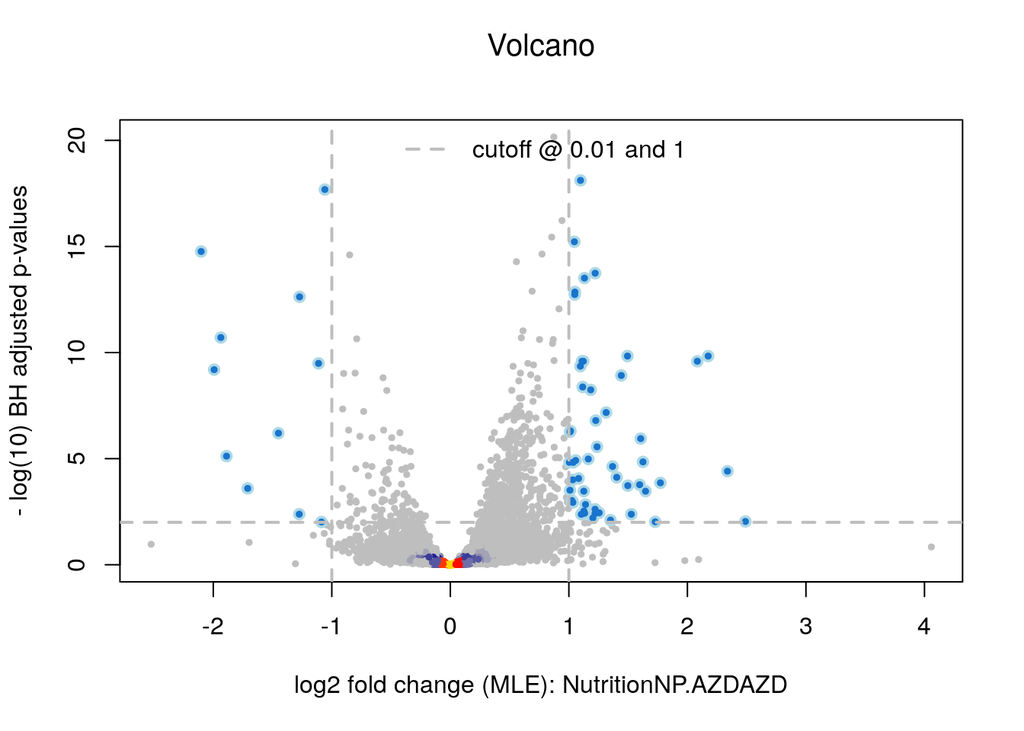

```r
volcanoPlot(res, lfc=1)
```

#### 6.4.4.4 Heatmap

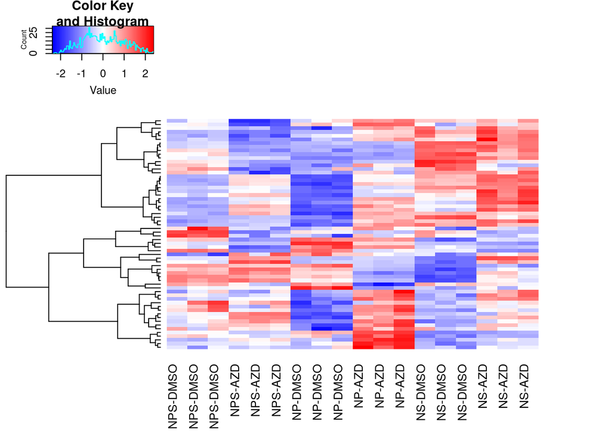

```r
hm <- heatmap.2(t(scale(t(vsd[cutoffs,]))),col=hpal,
                Colv=FALSE,dendrogram = "row",trace = "none",labRow = FALSE,
                distfun = pearson.dist, labCol = paste(samples$Nutrition,samples$AZD,sep="-")[sel],
                hclustfun = function(X){hclust(X,method="ward.D2")},margins = c(6,5))
```

### 6.4.5 Differential response of AZD & phosphorus starvation from AZD + phosphorus starvation responses

#### 6.4.5.1 Extraction of the results from the DESeq analysis

```r
res <- results(dds,name = "NutritionNS.AZDAZD")
data <- data.frame(rownames(res), res$log2FoldChange, res$padj)
write.table(data, file = "NutritionNS.AZDAZD_6h.csv", sep = ";", row.names = FALSE, dec=",")
cutoffs <- abs(res$log2FoldChange) >= lfc & ! is.na(res$padj) & res$padj <= FDR
cutoff1 <- res$log2FoldChange >= lfc & ! is.na(res$padj) & res$padj <= FDR
cutoff2 <- res$log2FoldChange <= -lfc & ! is.na(res$padj) & res$padj <= FDR
Azd_NS6hrs <- rownames(res[cutoffs,])
Azd_NSLow6hrs <- rownames(res[cutoff2,])
Azd_NSHigh6hrs <- rownames(res[cutoff1,])

message(sprintf("There are %s genes that are differentially expressed",sum(cutoffs)))
```

```
## There are 656 genes that are differentially expressed
```

```r
message(sprintf("There are %s genes that are induced",sum(cutoff1)))
```

```
## There are 572 genes that are induced
```

```r
message(sprintf("There are %s genes that are repressed",sum(cutoff2)))
```

```
## There are 84 genes that are repressed
```

#### 6.4.5.2 MA plot

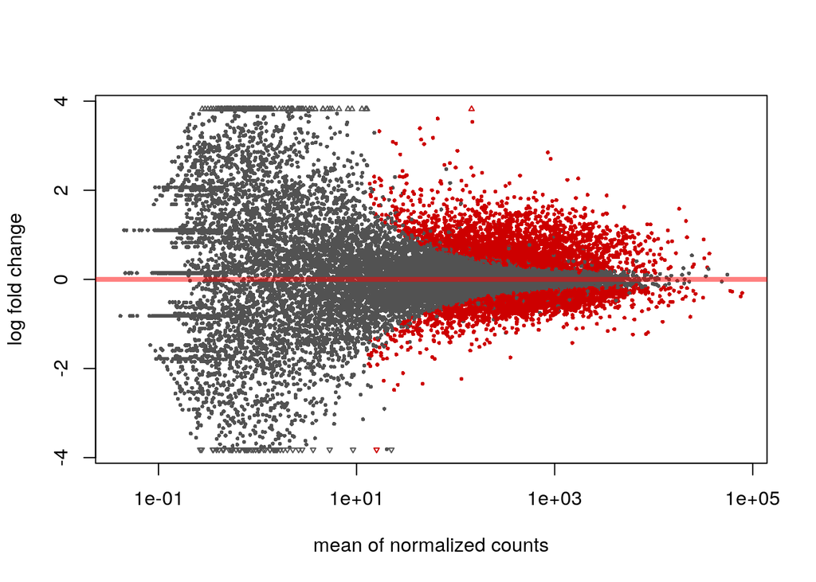

```r
DESeq2::plotMA(res)
```

#### 6.4.5.3 Volcano plot

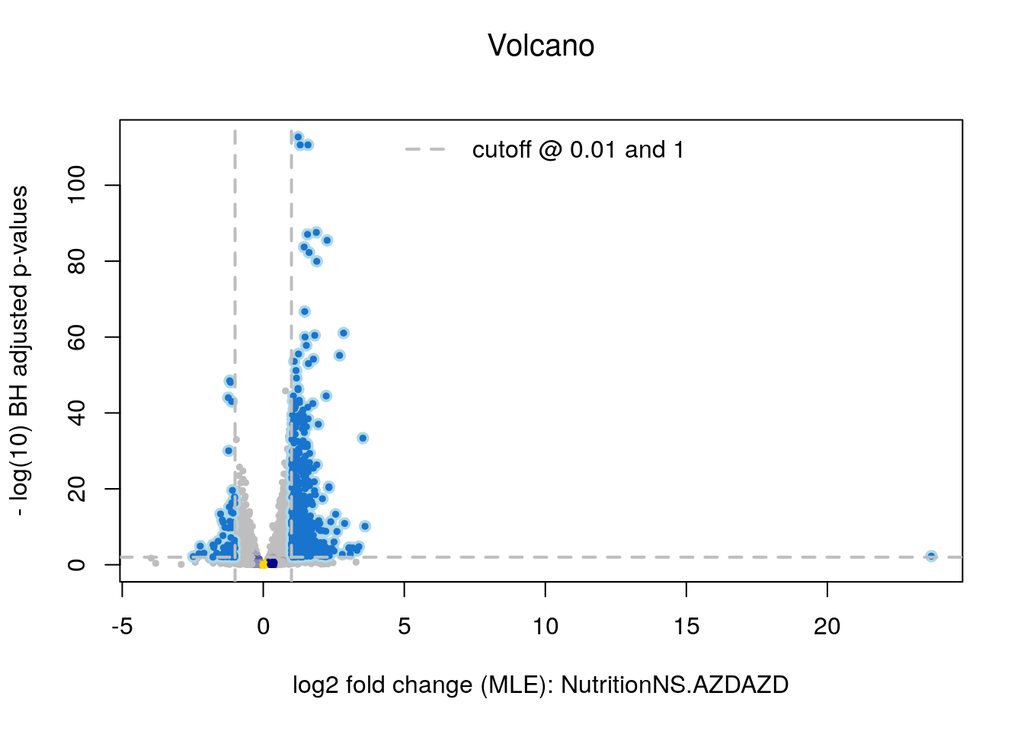

```r
volcanoPlot(res, lfc=1)
```

#### 6.4.5.4 Heatmap

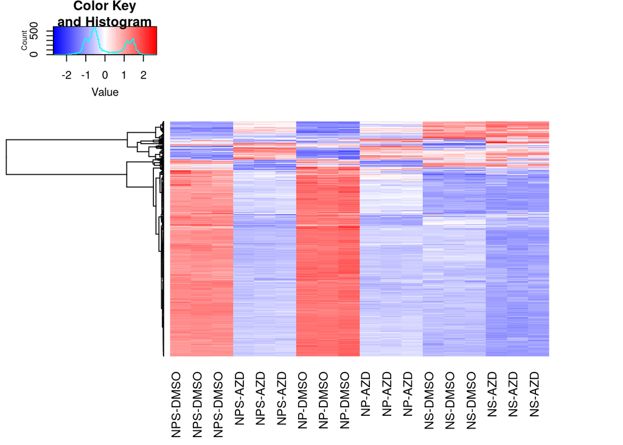

```r
hm <- heatmap.2(t(scale(t(vsd[cutoffs,]))),col=hpal,
                Colv=FALSE,dendrogram = "row",trace = "none",labRow = FALSE,
                distfun = pearson.dist, labCol = paste(samples$Nutrition,samples$AZD,sep="-")[sel],
                hclustfun = function(X){hclust(X,method="ward.D2")},margins = c(6,5))
```

# 7 Differential expression based on the nutrition and treatment at T24

## 7.1 Filtration of samples based on timepoint

```r
samples %<>% mutate(Conditions,Conditions=relevel(Conditions,"T24_NPS_DMSO"))
sel <- samples$Timepoint %in% c("T24")
suppressMessages(dds <- DESeqDataSetFromMatrix(
    countData = kg[,sel],
    colData = samples[sel,],
    design = ~ Nutrition * AZD))
```

## 7.2 Differential expression analysis

```r
dds <- DESeq(dds)
```

## 7.3 Variance Stabilising Transformation

### 7.3.1 Perform a Variance Stabilizing Transformation for plotting

```r
vst <- varianceStabilizingTransformation(dds,blind=FALSE)
vsd <- assay(vst)
vsd <- vsd - min(vsd)
```

## 7.4 Contrasts to NPS_DMSO

The contrast by default is the first one (not Intercept)

```r
resultsNames(dds)
```

```
## [1] "Intercept"           "Nutrition_NP_vs_NPS" "Nutrition_NS_vs_NPS"
## [4] "AZD_AZD_vs_DMSO"     "NutritionNP.AZDAZD"  "NutritionNS.AZDAZD"
```

### 7.4.1 Nutrition effect of carbon starvation

```r
# See output of "Condition design"
```

### 7.4.2 Nutrition effect of phosphorus starvation

```r
# See output of "Condition design"
```

### 7.4.3 Effect of AZD-8055

```r
# See output of "Condition design"
```

### 7.4.4 Differential response of AZD & sugar starvation from AZD + sugar starvation responses

#### 7.4.4.1 Extraction of the results from the DESeq analysis

```r
res <- results(dds,name = "NutritionNP.AZDAZD")
data <- data.frame(rownames(res), res$log2FoldChange, res$padj)
write.table(data, file = "NutritionNP.AZDAZD_24h.csv", sep = ";", row.names = FALSE, dec=",")
cutoffs <- abs(res$log2FoldChange) >= lfc & ! is.na(res$padj) & res$padj <= FDR
cutoff1 <- res$log2FoldChange >= lfc & ! is.na(res$padj) & res$padj <= FDR
cutoff2 <- res$log2FoldChange <= -lfc & ! is.na(res$padj) & res$padj <= FDR
Azd_NP24hrs <- rownames(res[cutoffs,])
Azd_NPLow24hrs <- rownames(res[cutoff2,])
Azd_NPHigh24hrs <- rownames(res[cutoff1,])

message(sprintf("There are %s genes that are differentially expressed",sum(cutoffs)))
```

```
## There are 1444 genes that are differentially expressed
```

```r
message(sprintf("There are %s genes that are induced",sum(cutoff1)))
```

```
## There are 870 genes that are induced
```

```r
message(sprintf("There are %s genes that are repressed",sum(cutoff2)))
```

```
## There are 574 genes that are repressed
```

#### 7.4.4.2 MA plot

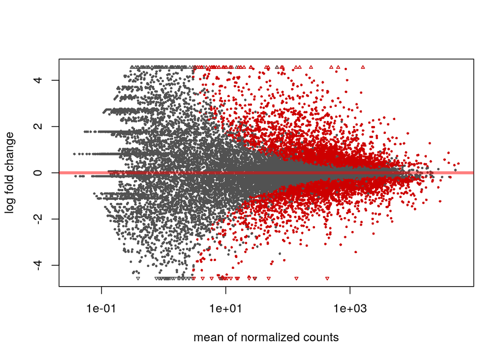

```r
DESeq2::plotMA(res)
```

#### 7.4.4.3 Volcano plot

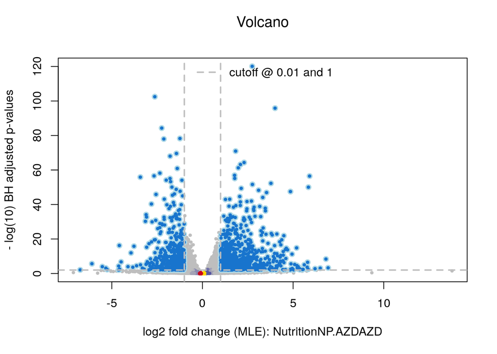

```r
volcanoPlot(res, lfc=1)
```

#### 7.4.4.4 Heatmap

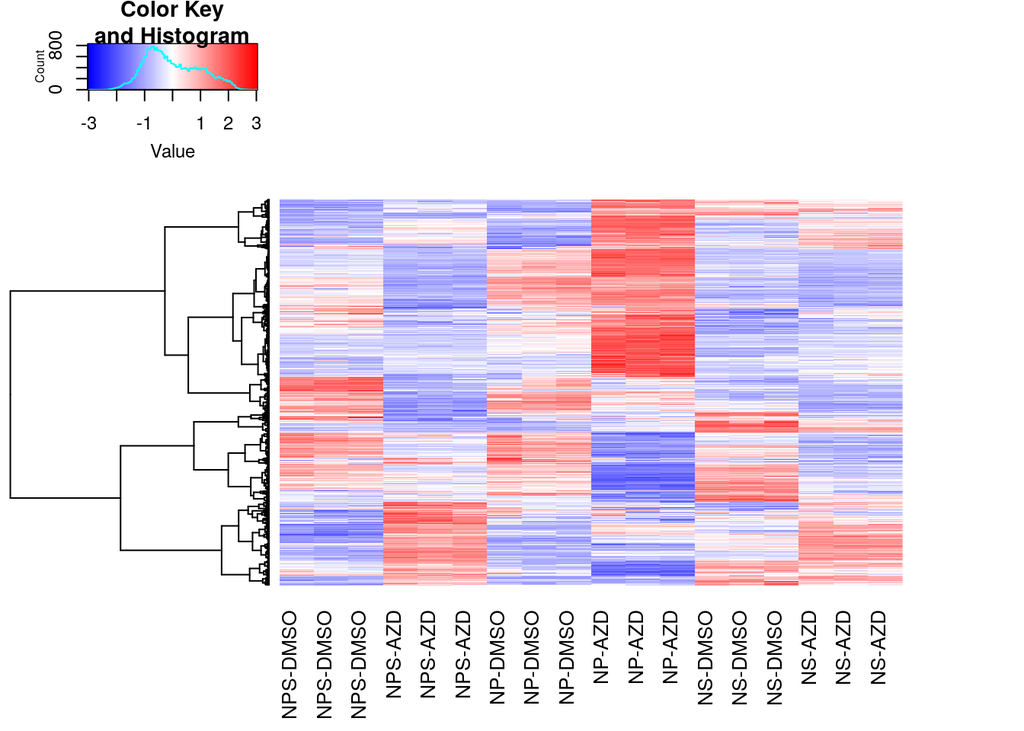

```r
hm <- heatmap.2(t(scale(t(vsd[cutoffs,]))),col=hpal,
                Colv=FALSE,dendrogram = "row",trace = "none",labRow = FALSE,
                distfun = pearson.dist, labCol = paste(samples$Nutrition,samples$AZD,sep="-")[sel],
                hclustfun = function(X){hclust(X,method="ward.D2")},margins = c(6,5))
```

### 7.4.5 Differential response of AZD & phosphorus starvation from AZD + phosphorus starvation responses

#### 7.4.5.1 Extraction of the results from the DESeq analysis

```r
res <- results(dds,name = "NutritionNS.AZDAZD")
data <- data.frame(rownames(res), res$log2FoldChange, res$padj)
write.table(data, file = "NutritionNS.AZDAZD_24h.csv", sep = ";", row.names = FALSE, dec=",")
cutoffs <- abs(res$log2FoldChange) >= lfc & ! is.na(res$padj) & res$padj <= FDR
cutoff1 <- res$log2FoldChange >= lfc & ! is.na(res$padj) & res$padj <= FDR
cutoff2 <- res$log2FoldChange <= -lfc & ! is.na(res$padj) & res$padj <= FDR
Azd_NS24hrs <- rownames(res[cutoffs,])
Azd_NSLow24hrs <- rownames(res[cutoff2,])
Azd_NSHigh24hrs <- rownames(res[cutoff1,])

message(sprintf("There are %s genes that are differentially expressed",sum(cutoffs)))
```

```
## There are 2588 genes that are differentially expressed
```

```r
message(sprintf("There are %s genes that are induced",sum(cutoff1)))
```

```
## There are 1124 genes that are induced
```

```r
message(sprintf("There are %s genes that are repressed",sum(cutoff2)))
```

```
## There are 1464 genes that are repressed
```

#### 7.4.5.2 MA plot

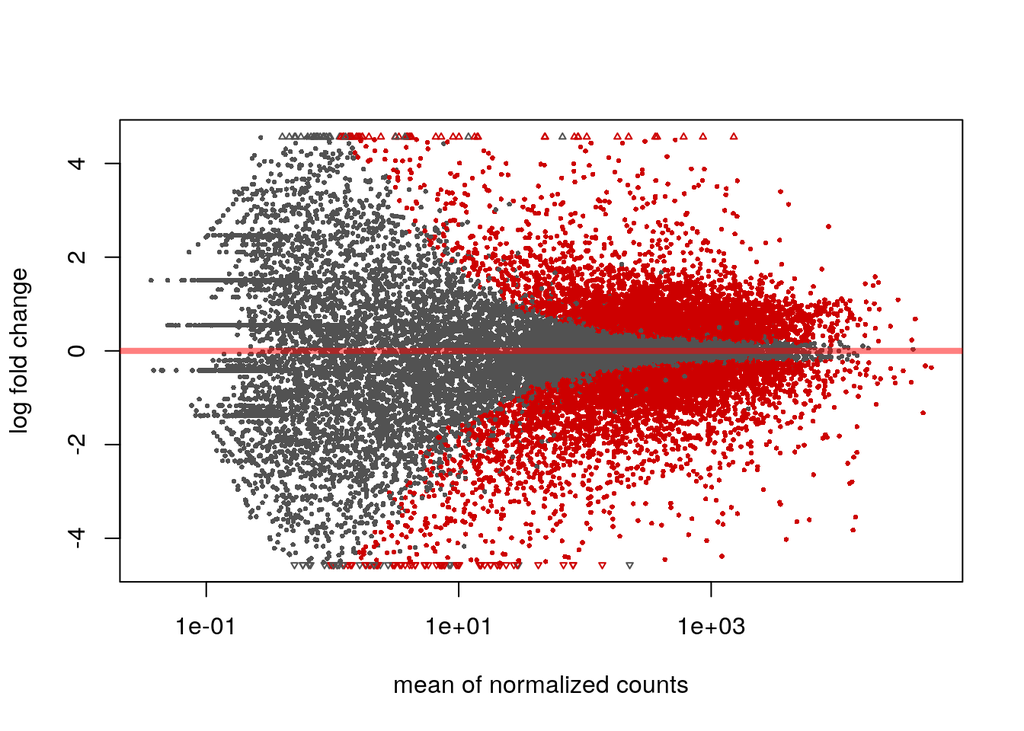

```r
DESeq2::plotMA(res)
```

#### 7.4.5.3 Volcano plot

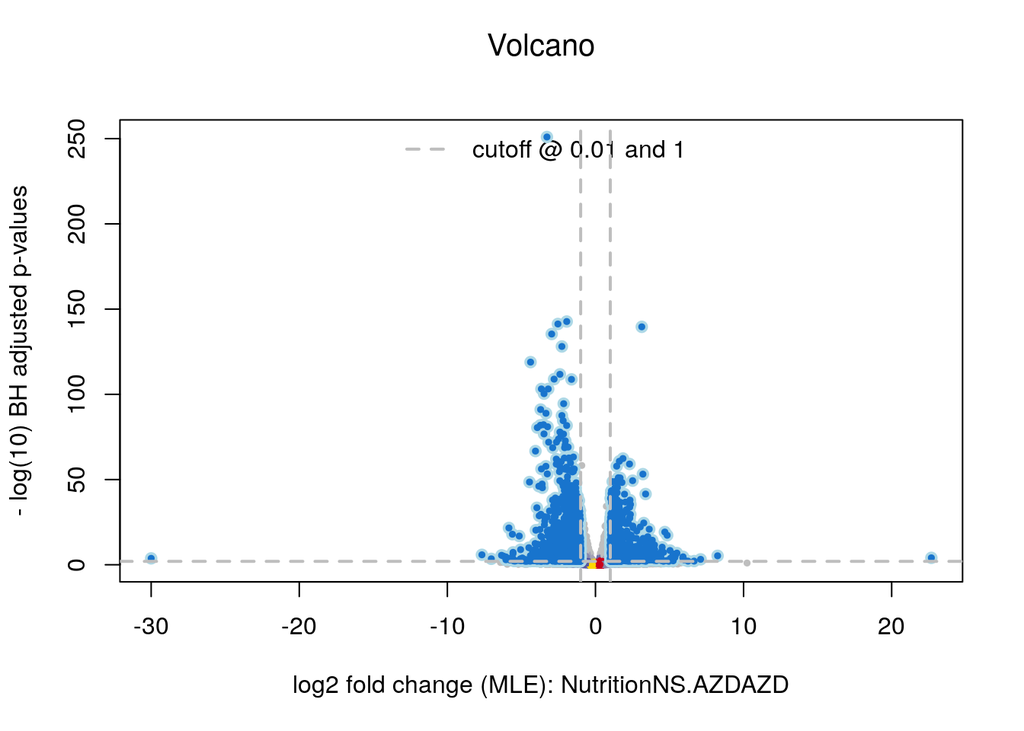

```r
volcanoPlot(res, lfc=1)
```

#### 7.4.5.4 Heatmap

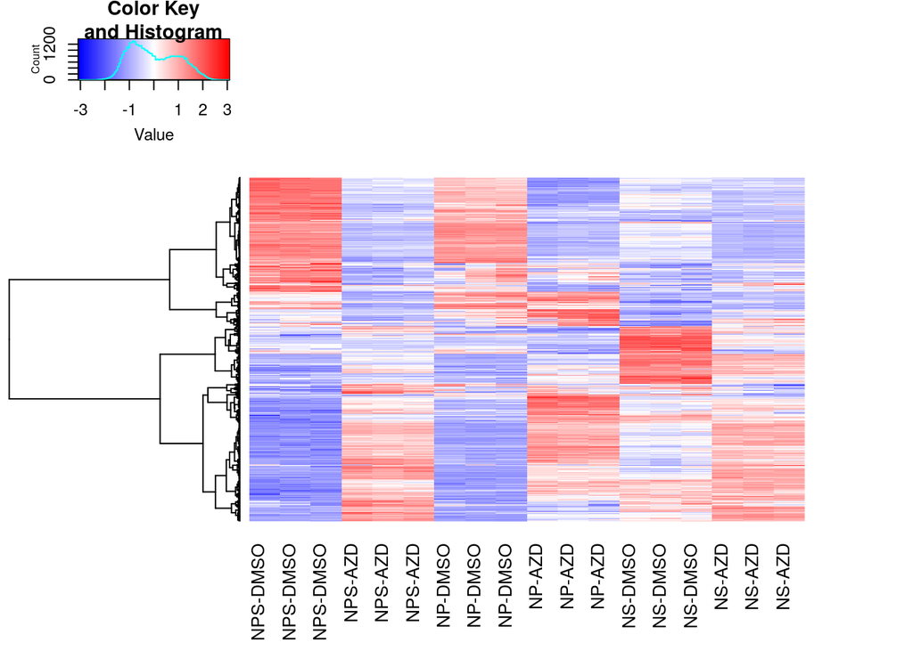

```r
hm <- heatmap.2(t(scale(t(vsd[cutoffs,]))),col=hpal,
                Colv=FALSE,dendrogram = "row",trace = "none",labRow = FALSE,
                distfun = pearson.dist, labCol = paste(samples$Nutrition,samples$AZD,sep="-")[sel],
                hclustfun = function(X){hclust(X,method="ward.D2")},margins = c(6,5))
```

# 8 Export list of DEGs

```r
write.table(Azd_NPLow6hrs, file = "Azd_NPLow6hrs.csv", sep = ";", row.names = FALSE)
write.table(Azd_NPHigh6hrs, file = "Azd_NPHigh6hrs.csv", sep = ";", row.names = FALSE)

write.table(Azd_NSLow6hrs, file = "Azd_NSLow6hrs.csv", sep = ";", row.names = FALSE)
write.table(Azd_NSHigh6hrs, file = "Azd_NSHigh6hrs.csv", sep = ";", row.names = FALSE)

write.table(Azd_NPLow24hrs, file = "Azd_NPLow24hrs.csv", sep = ";", row.names = FALSE)
write.table(Azd_NPHigh24hrs, file = "Azd_NPHigh24hrs.csv", sep = ";", row.names = FALSE)

write.table(Azd_NSLow24hrs, file = "Azd_NSLow24hrs.csv", sep = ";", row.names = FALSE)
write.table(Azd_NSHigh24hrs, file = "Azd_NSHigh24hrs.csv", sep = ";", row.names = FALSE)
```

# 9 GO enrichment analysis

## 9.1 For the interaction before AZD and sugar starvation

- Induced genes after 6hrs

```r
GO <- gopher(Azd_NPHigh6hrs,background=rownames(vsd)[rowSums(vsd)>0],url="athaliana", alpha=2)
```

```
## No enrichments found in task: mapman
```

```r
write.table(GO$go, file = "GO_Azd_NPHigh6hrs.csv", sep = ";", row.names = FALSE)
write.table(GO$kegg, file = "KEGG_Azd_NPHigh6hrs.csv", sep = ";", row.names = FALSE)
write.table(GO$pfam, file = "PFAM_Azd_NPHigh6hrs.csv", sep = ";", row.names = FALSE)
```

- Induced genes after 24hrs

```r
GO <- gopher(Azd_NPHigh24hrs,background=rownames(vsd)[rowSums(vsd)>0],url="athaliana",alpha=2)
```

```
## No enrichments found in task: mapman
```

```r
write.table(GO$go, file = "GO_Azd_NPHigh24hrs.csv", sep = ";", row.names = FALSE)
write.table(GO$kegg, file = "KEGG_Azd_NPHigh24hrs.csv", sep = ";", row.names = FALSE)
write.table(GO$pfam, file = "PFAM_Azd_NPHigh24hrs.csv", sep = ";", row.names = FALSE)
```

- Repressed genes after 6hrs

```r
GO <- gopher(Azd_NPLow6hrs,background=rownames(vsd)[rowSums(vsd)>0],url="athaliana",alpha=2)
```

```
## No enrichments found in task: mapman
```

```r
write.table(GO$go, file = "GO_Azd_NPLow6hrs.csv", sep = ";", row.names = FALSE)
write.table(GO$kegg, file = "KEGG_Azd_NPLow6hrs.csv", sep = ";", row.names = FALSE)
write.table(GO$pfam, file = "PFAM_Azd_NPLow6hrs.csv", sep = ";", row.names = FALSE)
```

- Repressed genes after 24hrs

```r
GO <- gopher(Azd_NPLow24hrs,background=rownames(vsd)[rowSums(vsd)>0],url="athaliana",alpha=2)
```

```
## No enrichments found in task: mapman
```

```r
write.table(GO$go, file = "GO_Azd_NPLow24hrs.csv", sep = ";", row.names = FALSE)
write.table(GO$kegg, file = "KEGG_Azd_NPLow24hrs.csv", sep = ";", row.names = FALSE)
write.table(GO$pfam, file = "PFAM_Azd_NPLow24hrs.csv", sep = ";", row.names = FALSE)
```

## 9.2 For the interaction between AZD and phosphorus starvation

- Induced genes after 6hrs

```r
GO <- gopher(Azd_NSHigh6hrs,background=rownames(vsd)[rowSums(vsd)>0],url="athaliana", alpha=2)
```

```
## No enrichments found in task: mapman
```

```r
write.table(GO$go, file = "GO_Azd_NSHigh6hrs.csv", sep = ";", row.names = FALSE)
write.table(GO$kegg, file = "KEGG_Azd_NSHigh6hrs.csv", sep = ";", row.names = FALSE)
write.table(GO$pfam, file = "PFAM_Azd_NSHigh6hrs.csv", sep = ";", row.names = FALSE)
```

- Induced genes after 24hrs

```r
GO <- gopher(Azd_NSHigh24hrs,background=rownames(vsd)[rowSums(vsd)>0],url="athaliana", alpha=2)
```

```
## No enrichments found in task: mapman
```

```r
write.table(GO$go, file = "GO_Azd_NSHigh24hrs.csv", sep = ";", row.names = FALSE)
write.table(GO$kegg, file = "KEGG_Azd_NSHigh24hrs.csv", sep = ";", row.names = FALSE)
write.table(GO$pfam, file = "PFAM_Azd_NSHigh24hrs.csv", sep = ";", row.names = FALSE)
```

- Repressed genes after 6hrs

```r
GO <- gopher(Azd_NSLow6hrs,background=rownames(vsd)[rowSums(vsd)>0],url="athaliana", alpha=2)
```

```
## No enrichments found in task: mapman
```

```r
write.table(GO$go, file = "GO_Azd_NSLow6hrs.csv", sep = ";", row.names = FALSE)
write.table(GO$kegg, file = "KEGG_Azd_NSLow6hrs.csv", sep = ";", row.names = FALSE)
write.table(GO$pfam, file = "PFAM_Azd_NSLow6hrs.csv", sep = ";", row.names = FALSE)
```

- Repressed genes after 24hrs

```r
GO <- gopher(Azd_NSLow24hrs,background=rownames(vsd)[rowSums(vsd)>0],url="athaliana", alpha=2)
```

```
## No enrichments found in task: mapman
```

```r
write.table(GO$go, file = "GO_Azd_NSLow24hrs.csv", sep = ";", row.names = FALSE)
write.table(GO$kegg, file = "KEGG_Azd_NSLow24hrs.csv", sep = ";", row.names = FALSE)
write.table(GO$pfam, file = "PFAM_Azd_NSLow24hrs.csv", sep = ";", row.names = FALSE)
```